# simcausal

Yazhuo Deng

January 15, 2019

## 0.1 Simulation study with single time point interventions.

### 0.1.1 Specifying parametric structural equation models in simcausal

The following example code defines the distributions of (I,W,A). Specifically, we use the pre-defined R functions `rcat.b1`, `rnorm`, `runif` and `rbern` to define the latent categorical node `I`, normal node `W1`, uniform node `W2` and Bernoulli nodes `W3` and `A`, respectively.

```r
library("simcausal")
D <- DAG.empty()
D <- D +
  node("I", distr = "rcat.b1",
       probs = c(0.1, 0.2, 0.2, 0.2, 0.1, 0.1, 0.1)) +
  node("W1", distr = "rnorm",
       mean = ifelse(I == 1, 0, ifelse(I == 2, 3, 10)) + 0.6 * I, sd = 1) +
  node("W2", distr = "runif",
       min = 0.025*I, max = 0.7*I) +
  node("W3", distr = "rbern",
       prob = plogis(-0.5 + 0.7*W1 + 0.3*W2 - 0.2*I)) +
  node("A", distr = "rbern",
       prob = plogis(+4.2 - 0.5*W1 + 0.1*W2 + 0.2*W3))
```

we assume that the outcome Y is influenced by an independent latent error $U_Y \sim N(0,1)$, and we use the following code example to show how one might explicitly define $U_Y$ using a node named “`U.Y`”.

```r
D <- D + node("U.Y", distr = "rnorm", mean = 0, sd = 1)

D <- D + node("Y", distr = "rconst",
              const = -0.5 + 1.2*A + 0.2*I + 0.1*W1 + 0.3*W2 + 0.2*W3 + U.Y)

Dset1 <- set.DAG(D, latent.v = c("I", "U.Y"))
```

```
## ...automatically assigning order attribute to some nodes...
```

```
## node I, order:1
```

```
## node W1, order:2
```

```
## node W2, order:3
```

```
## node W3, order:4
```

```
## node A, order:5
```

```
## node U.Y, order:6
```

```
## node Y, order:7
```

```r
str(Dset1)
```

```
## List of 7
##  $ I  :List of 8
##   ..$ name       : chr "I"
##   ..$ mv.names   : chr "I"
##   ..$ t          : NULL
##   ..$ distr      : chr "rcat.b1"
##   ..$ dist_params:List of 1
##   .. ..$ probs: chr "c(0.1, 0.2, 0.2, 0.2, 0.1, 0.1, 0.1)"
##   .. ..- attr(*, "asis.flags")=List of 1
##   .. .. ..$ probs: logi FALSE
##   ..$ EFU        : NULL
##   ..$ order      : num 1
##   ..$ node.env   :<environment: R_GlobalEnv>
##   ..- attr(*, "class")= chr "DAG.node"
##  $ W1 :List of 8
##   ..$ name       : chr "W1"
##   ..$ mv.names   : chr "W1"
##   ..$ t          : NULL
##   ..$ distr      : chr "rnorm"
##   ..$ dist_params:List of 2
##   .. ..$ mean: chr "ifelse(I == 1, 0, ifelse(I == 2, 3, 10)) + 0.6 * I"
##   .. ..$ sd  : chr "1"
##   .. ..- attr(*, "asis.flags")=List of 2
##   .. .. ..$ mean: logi FALSE
##   .. .. ..$ sd  : logi FALSE
##   ..$ EFU        : NULL
##   ..$ order      : num 2
##   ..$ node.env   :<environment: R_GlobalEnv>
##   ..- attr(*, "class")= chr "DAG.node"
##  $ W2 :List of 8
##   ..$ name       : chr "W2"
##   ..$ mv.names   : chr "W2"
##   ..$ t          : NULL
##   ..$ distr      : chr "runif"
##   ..$ dist_params:List of 2
##   .. ..$ min: chr "0.025 * I"
##   .. ..$ max: chr "0.7 * I"
##   .. ..- attr(*, "asis.flags")=List of 2
##   .. .. ..$ min: logi FALSE
##   .. .. ..$ max: logi FALSE
```

[output cut: 56 more lines]

```
##   ..$ node.env   :<environment: R_GlobalEnv>
##   ..- attr(*, "class")= chr "DAG.node"
##  - attr(*, "class")= chr "DAG"
##  - attr(*, "user.env")=<environment: R_GlobalEnv>
##  - attr(*, "latent.v")= chr [1:2] "I" "U.Y"
##  - attr(*, "n.test")= num 10
##  - attr(*, "parents")=List of 7
##   ..$ I  : chr(0)
##   ..$ W1 : chr "I"
##   ..$ W2 : chr "I"
##   ..$ W3 : chr [1:3] "W1" "W2" "I"
##   ..$ A  : chr [1:3] "W1" "W2" "W3"
##   ..$ U.Y: chr(0)
##   ..$ Y  : chr [1:6] "A" "I" "W1" "W2" ...
##  - attr(*, "locked")= logi TRUE
```

we modify the above SEM for Y and allow for the effect of treatment on Y to vary by strata of W3

```r
D <- D + node("Y", distr = "rconst",
              const = -0.5 + 1.2*A - 0.5*(A * W3) + 0.2*I +
                0.2*(W1 + W2 + W3) + U.Y)
```

```
## existing node Y was modified
```

```r
Dset2 <- set.DAG(D, latent.v = c("I", "U.Y"))
```

```
## ...automatically assigning order attribute to some nodes...
```

```
## node I, order:1
```

```
## node W1, order:2
```

```
## node W2, order:3
```

```
## node W3, order:4
```

```
## node A, order:5
```

```
## node U.Y, order:6
```

```
## node Y, order:7
```

For our final example shown below, we re-define Y as a nonlinear function of the same parent nodes used in the previous two examples. Note that in this model for the outcome Y , the analytic derivation of the ATE becomes intractable. However, one can use simcausal to find a Monte-Carlo approxi- mation of the ATE from simulated counterfactual data.

```r
D <- D +
  node("Y", distr = "rconst", const =
         +1.2*A + 0.05*(W1^2 + W2^3 / 10 + W3) + 0.7*abs(U.Y) +
         0.002*I^2 + +0.02*abs(1 / sin(U.Y * W2 + A)) *
         (abs(1/sin(U.Y * W2)) <= 10) + +5*(abs(1/sin(U.Y * W2)) > 10))
```

```
## existing node Y was modified
```

```r
Dset3 <- set.DAG(D, latent.v = c("I", "U.Y"))
```

```
## ...automatically assigning order attribute to some nodes...
```

```
## node I, order:1
```

```
## node W1, order:2
```

```
## node W2, order:3
```

```
## node W3, order:4
```

```
## node A, order:5
```

```
## node U.Y, order:6
```

```
## node Y, order:7
```

```
## using the following vertex attributes:
```

```
## NAdarkbluenone100.50
```

```
## using the following edge attributes:
```

```
## black0.210.60.5
```

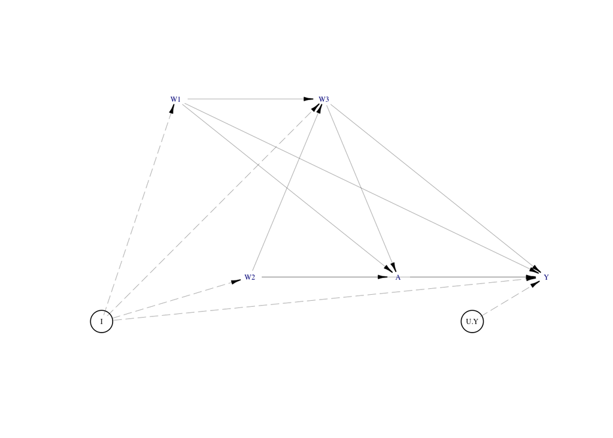

```r
plotDAG(Dset3)
```

### 0.1.2 Simulating observed data (`sim`)

an example of how to simulate an observed dataset with 10,000 observations using the causal model defined in the previous section. The output is a `data.frame` object.

```r
Odat <- sim(DAG = Dset3, n = 10000, rndseed = 123)
```

```
## simulating observed dataset from the DAG object
```

```r
Odat[1,]
```

```
##   ID       W1        W2 W3 A        Y
## 1  1 3.705826 0.1686546  1 1 7.080206
```

### 0.1.3 Specifying interventions (`+ action`)

The first action named “`A1`” consists in replacing the distribution of the treatment node `A` with the degenerate distribution at value 1. The second action named “`A0`” consists in replacing the distribution of the treatment node `A` with the degenerate distribution at value 0.

```r
A1 <- node("A", distr = "rbern", prob = 1)
Dset3 <- Dset3 + action("A1", nodes = A1)
A0 <- node("A", distr = "rbern", prob = 0)
Dset3 <- Dset3 + action("A0", nodes = A0)

names(A(Dset3))
```

```
## [1] "A1" "A0"
```

```r
class(A(Dset3)[["A0"]])
```

```
## [1] "DAG.action"
```

### 0.1.4 Simulating counterfactual data (`sim`)

```r
Xdat1 <- sim(DAG = Dset3, actions = c("A1", "A0"),
             n = 100000, rndseed = 123)
```

```
## simulating action-specific datasets for action(s): A1 A0
```

```r
names(Xdat1)
```

```
## [1] "A1" "A0"
```

```r
dim(Xdat1[["A1"]])
```

```
## [1] 100000      6
```

```r
dim(Xdat1[["A0"]])
```

```
## [1] 100000      6
```

```r
table(Xdat1[["A1"]]$A)
```

```
##
##      1
## 100000
```

```r
table(Xdat1[["A0"]]$A)
```

```
##
##      0
## 100000
```

```r
Xdat1[["A1"]][1, ]
```

```
##   ID      W1       W2 W3 A        Y
## 1  1 4.45959 1.120454  1 1 2.834955
```

```r
Xdat1[["A0"]][1, ]
```

```
##   ID      W1       W2 W3 A        Y
## 1  1 4.45959 1.120454  1 0 1.573187
```

### 0.1.5 Defining and evaluating various causal target parameters

Causal parameters defined with `set.targetE`

The first example below defines the causal quantity of interest as the expectation of node `Y` under action “`A1`”, i.e., $E(Y_1)$.

The true value of the above causal parameter is now evaluated by calling the function `eval.target` and passing the previously simulated counterfactual data object `Xdat1`.

```r
Dset3 <- set.targetE(Dset3, outcome = "Y", param = "A1")

eval.target(Dset3, data = Xdat1)$res
```

```
##   Mean_Y
## 8.666479
```

Alternatively, `eval.target` can be called without the simulated counterfactual data, specifying the sample size argument n instead. In this case a counterfactual dataset with the user-specified sample size is simulated first.

```r
eval.target(Dset3, n = 100000, rndseed = 123)$res
```

```
## data not specified, simulating full data
```

```
## no actions specified, sampling full data for ALL actions from the DAG
```

```
## evaluating the target on 1e+05 simulated samples per action
```

```
##   Mean_Y
## 8.666479
```

The example below defines the causal target parameter as the ATE on the additive scale, i.e., the expectation of Y under action “`A1`” minus its expectation under action “`A0`”, given by $E(Y_1 −Y_0)$:

```r
Dset3 <- set.targetE(Dset3, outcome = "Y", param = "A1-A0")
eval.target(Dset3, data = Xdat1)$res
```

```
##   Diff_Y
## 1.281203
```

Similarly, the ATE on the multiplicative scale given by $E(Y_1)/E(Y_0)$ can be evaluated as follows:

```r
Dset3 <- set.targetE(Dset3, outcome = "Y", param = "A1/A0")
eval.target(Dset3, data = Xdat1)$res
```

```
##  Ratio_Y
## 1.173481
```

### 0.1.6 Causal parameters defined with set.targetMSM

```r
newA <- node("A", distr = "rbern", prob = d)
Dset3 <- Dset3 + action("A1", nodes = newA, d = 1)
Dset3 <- Dset3 + action("A0", nodes = newA, d = 0)

msm.form <- "Y ~ d"
Dset3 <- set.targetMSM(Dset3, outcome = "Y", form = msm.form,
                       family = "gaussian")
msm.res <- eval.target(Dset3, n = 100000, rndseed = 123)
```

```
## data not specified, simulating full data
```

```
## no actions specified, sampling full data for ALL actions from the DAG
```

```
## evaluating the target on 1e+05 simulated samples per action
```

```
## MSM: fitting glm to full data
```

```r
msm.res$coef
```

```
## (Intercept)           d
##    7.385276    1.281203
```

## 0.2 Simulation study with multiple time point interventions

```r
D <- DAG.empty()
D <- D +
  node("L2", t = 0, distr = "rbern", prob = 0.05) +
  node("L1", t = 0, distr = "rbern",
       prob = ifelse(L2[0] == 1, 0.5, 0.1)) +
  node("A1", t = 0, distr = "rbern",
       prob =
         ifelse(L1[0] == 1 & L2[0] == 0, 0.5,
                ifelse(L1[0] == 0 & L2[0] == 0, 0.1,
                       ifelse(L1[0] == 1 & L2[0] == 1, 0.9, 0.5))))
```

```r
t.end <- 16
D <- D +
  node("Y", t = 1:t.end, distr = "rbern",
       prob =
         plogis(-6.5 + L1[0] + 4 * L2[t-1] +
                  0.05 * sum(I(L2[0:(t-1)] == rep(0, t)))),
       EFU = TRUE) +
  node("L2", t = 1:t.end, distr = "rbern",
       prob =
         ifelse(A1[t-1] == 1, 0.1,
                ifelse(L2[t-1] == 1, 0.9, min(1, 0.1 + t / 16)))) +
  node("A1", t = 1:t.end, distr = "rbern", prob =
         ifelse(A1[t-1] == 1, 1,
                ifelse(L1[0] == 1 & L2[t] == 0, 0.3,
                       ifelse(L1[0] == 0 & L2[t] == 0, 0.1,
                              ifelse(L1[0] == 1 & L2[t] == 1, 0.7, 0.5)))))
lDAG <- set.DAG(D)
```

```
## ...automatically assigning order attribute to some nodes...
```

```
## node L2_0, order:1
```

```
## node L1_0, order:2
```

```
## node A1_0, order:3
```

```
## node Y_1, order:4
```

```
## node L2_1, order:5
```

```
## node A1_1, order:6
```

```
## node Y_2, order:7
```

```
## node L2_2, order:8
```

```
## node A1_2, order:9
```

```
## node Y_3, order:10
```

```
## node L2_3, order:11
```

```
## node A1_3, order:12
```

```
## node Y_4, order:13
```

```
## node L2_4, order:14
```

```
## node A1_4, order:15
```

```
## node Y_5, order:16
```

```
## node L2_5, order:17
```

```
## node A1_5, order:18
```

```
## node Y_6, order:19
```

```
## node L2_6, order:20
```

```
## node A1_6, order:21
```

```
## node Y_7, order:22
```

```
## node L2_7, order:23
```

```
## node A1_7, order:24
```

```
## node Y_8, order:25
```

```
## node L2_8, order:26
```

```
## node A1_8, order:27
```

```
## node Y_9, order:28
```

```
## node L2_9, order:29
```

```
## node A1_9, order:30
```

```
## node Y_10, order:31
```

```
## node L2_10, order:32
```

```
## node A1_10, order:33
```

```
## node Y_11, order:34
```

```
## node L2_11, order:35
```

```
## node A1_11, order:36
```

```
## node Y_12, order:37
```

```
## node L2_12, order:38
```

```
## node A1_12, order:39
```

```
## node Y_13, order:40
```

```
## node L2_13, order:41
```

```
## node A1_13, order:42
```

```
## node Y_14, order:43
```

```
## node L2_14, order:44
```

```
## node A1_14, order:45
```

```
## node Y_15, order:46
```

```
## node L2_15, order:47
```

```
## node A1_15, order:48
```

```
## node Y_16, order:49
```

```
## node L2_16, order:50
```

```
## node A1_16, order:51
```

```
## using the following vertex attributes:
```

```
## NAdarkbluenone70.50
```

```
## using the following edge attributes:
```

```
## black0.210.30.2
```

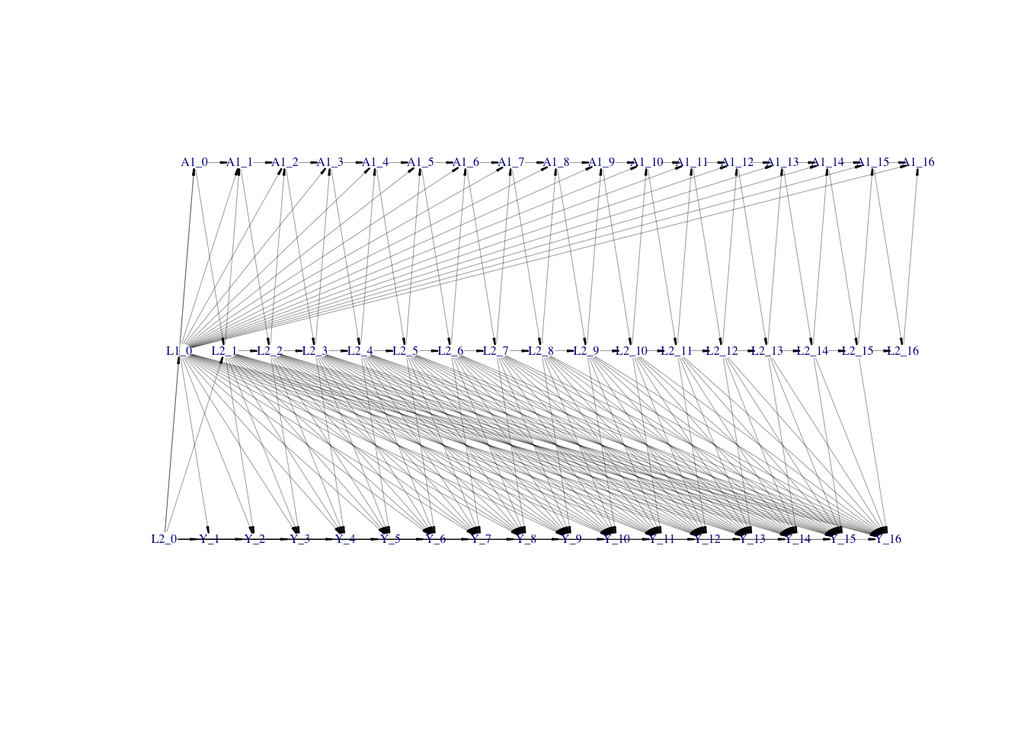

```r
plotDAG(lDAG)
```

### 0.2.1 Simulating observed data (`sim`)

```r
Odat <- sim(DAG = lDAG, n = 10000, rndseed = 123)
```

```
## simulating observed dataset from the DAG object
```

```r
Odat[1,]
```

```
##   ID L2_0 L1_0 A1_0 Y_1 L2_1 A1_1 Y_2 L2_2 A1_2 Y_3 L2_3 A1_3 Y_4 L2_4
## 1  1    0    0    1   0    0    1   0    0    1   0    1    1   0    0
##   A1_4 Y_5 L2_5 A1_5 Y_6 L2_6 A1_6 Y_7 L2_7 A1_7 Y_8 L2_8 A1_8 Y_9 L2_9
## 1    1   0    0    1   0    0    1   0    0    1   0    0    1   0    0
##   A1_9 Y_10 L2_10 A1_10 Y_11 L2_11 A1_11 Y_12 L2_12 A1_12 Y_13 L2_13 A1_13
## 1    1    0     0     1    0     0     1    0     0     1    0     0     1
##   Y_14 L2_14 A1_14 Y_15 L2_15 A1_15 Y_16 L2_16 A1_16
## 1    0     0     1    0     0     1    0     0     1
```